# stroopdata

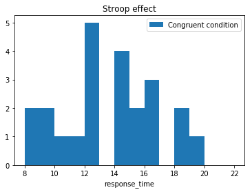

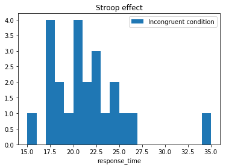

```python
cong,inco = stroop('./stroopdata.csv')
```

As you notice these histograms they seems bit of positively skewed distributions, which is pulling the mean to positive side but as you look upon our Mean values they are much closer to the peak which would indicate to the Normal Distribution.

```python
stref.index
```

```
RangeIndex(start=0, stop=24, step=1)
```

```python
stref['Participant']=stref.index+1
```

```python
import numpy as np
def scatterp(i,j):
    """
    This function reads the stroopdata file as per the arguments are passed which
    are the partipant and the respective words condition and creates a scatter plot according
    to given arguments.
    """
    x,y = stref[i],stref[j]
    colors = 'green'
    area = np.pi*15
    #colors = np.random.rand(N)
    ##area = np.pi * (15 * np.random.rand(N))**2
    fig = plt.figure()

    condition = 'Response Time ('+j+')'
    plt.xticks(np.arange(min(x), max(x)+1, 1))
    plt.yticks(np.arange(0, 35, 2))
    plt.scatter(x, y,s=area,c=colors, alpha=0.5)
    plt.title('Stroop effect')
    plt.xlabel(i)
    plt.ylabel(condition)
    plt.ylim([0,max(y)+1])
    plt.xlim([0,max(x)+1])
    plt.show()
```

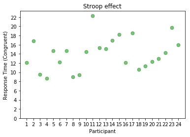

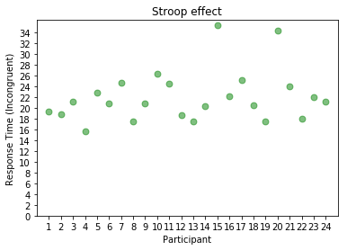

```python
scatterp('Participant','Congruent')
scatterp('Participant','Incongruent')
```

As you look through these scatterplots, In Congruent word condition's scatterplot the distribution is about between 8 to 22 and in the second Incongruent word condition's scatterplot has most of the distribution between like 15 to 26 and has two outliers around 35 that would possibly skew our distribution's mean value in order to make it less representative of our data.thus we can clearly see that the mean of the Participant's Response time to recognize the colour in Incongruent word condition is much greater than the Congruent word condition one.

Question 5. Now, perform the statistical test and report your results. What is your confidence level and your critical statistic value? Do you reject the null hypothesis or fail to reject it? Come to a conclusion in terms of the experiment task. Did the results match up with your expectations?  
Answer: We have done all the related calculations in the spreadsheet and link to the spreadsheet is here :

> **[Google Spreadsheet](https://docs.google.com/spreadsheets/d/1HWKRlJVVdR13A_wA-SC2qLv-5U9LUMCqSdd2AZDy3o0/edit#gid=1299780014)**  
> We first calculated the Mean of the Differences of sample set which is basically the **Point Estimate for μi-μc** which turns out to be = 7.964 whereas sample size is 24,  
> **Sample Standard Deviation of Differences** = 4.865  
> **Standard Error of the Differences**=0.9930286348  
> **t-statistic** is calculated by Mean of Differences minus the expected difference which is zero and dividing it by the Standard Error of the Differences which is equal to = 8.0207 whereas our  
> **t-critical** value is 1.714 for one tailed t-test at *α-level= 0.05* and for our *degrees of freedom = 23*.  
> As we can see here our t-statistic is much greater than our t-critical value in one tailed test at α=0.05 thus it is falling in the **critical region** and the p-value is very much less than p-value of 0.05 hence we will  
> **Reject the Null Hypothesis (Ho)** this means the Participants took significantly more amount of time to Response in the Incongruent words condition compared to the Congruent words Condition.  
> Since it was an experimental design we can make a causal statement like different word conditions have the causal effect on the participant's responce time to recognise the colour.  
> And Yes, the results are pretty much matched up with my expectations.

Question 6. Optional: What do you think is responsible for the effects observed? Can you think of an alternative or similar task that would result in a similar effect? Some research about the problem will be helpful for thinking about these two questions!  
Answer:-

> We Humans as habitual readers,we perform reading effortlessly whereas declaration of a colour requires more cognitive effort,and When there is a conflict between these two information(word & colour) our cognitive load is increased and our brain needs to concentrate on these differences which will eventually slow down our response time to recognise the colour.  
> kind of task that would result in similar effect is like if we write a name of perticular animal in a bit larger font and in one condition(Congruent) we will put pictures of that animal on the word font that describes animal and in another condition(Incongruent) we will put a different animal's pictures on that word which is referring to another animal regardless of pictures having on the word itself.  
> and here also my expectation is Incongruent condition will take more time to response to recognize the correct animal picture than the Congrgruent condition.

**References :**

> [Jupyter Notebook](https://hub.mybinder.org/user/ipython-ipython-in-depth-spaexsov/notebooks/binder/Index.ipynb)

(https://en.wikipedia.org/wiki/Stroop_effect)

(https://matplotlib.org/api/_as_gen/matplotlib.pyplot.scatter.html)

(https://pythonspot.com/matplotlib-scatterplot/)

(https://docs.google.com/spreadsheets/d/1HWKRlJVVdR13A_wA-SC2qLv-5U9LUMCqSdd2AZDy3o0/edit#gid=1299780014)

(https://docs.scipy.org/doc/numpy/reference/generated/numpy.arange.html)

(http://www.statisticshowto.com/sample-mean/)

(https://explorable.com/calculate-standard-deviation)

(https://imotions.com/blog/the-stroop-effect/)